# Supporting Material A

orchaRd 2.0: An R package for visualizing meta-analyses with orchard plots

Shinichi Nakagawa, Malgorzata Lagisz, Rose E. O’Dea, Patrice Pottier, Joanna Rutkowska, Alistair M. Senior, Yefeng Yang, and Daniel W.A. Noble

19 December 2022

```r
#knitter setting
knitr::opts_chunk$set(
message = FALSE,
warning = FALSE, # no warnings
cache = TRUE,# Caching to save time when knitting
tidy = TRUE,
echo = TRUE
#fig.width = 9
)

# cleaning up
#rm(list=ls())
```

## Setup

Loading packages and custom functions.

```r
pacman::p_load(tidyverse, # tidy family and related packages below
               readxl, #read Excel files
               kableExtra, # add features to a kable() output
               purrr,    #functional programming tools
               magrittr, # extending piping
               pander,   # nice tables
               plotly,     # interactive plots using ggplot2
               formatR, # provides a function tidy_source() to format R source automatically
               here #simplifying file paths
)
```

# Supplementary Methods and Results - Literature survey

## Literature search - methods

The original literature survey was conducted in 2019 to examine how forest plots are used in ecology and evolution, and what features they have. The resulting dataset was used in the original orchard plot publication:

Nakagawa, S., Lagisz, M., O’Dea, R. E., Rutkowska, J., Yang, Y., Noble, D. W., & Senior, A. M. (2020). The Orchard Plot: Cultivating a Forest Plot for Use in Ecology, Evolution and Beyond. Research Synthesis Methods https://doi.org/10.1002/jrsm.1424 12: 4-12 (EcoEvoRxiv https://doi.org/10.32942/osf.io/epqa7)

Here is a brief description of the systematic search of ecology and evolution journals underlying the data set from the SI materials from the above paper: “In brief, we collected the ISSN of journals classified under ‘Ecology’ and/or ‘Evolutionary Biology’, according to the ISI InCites Journal Citation Reports. We then searched within these journals for papers published between 1 January 2010 and 25 March 2019, and which contained any of the following search terms in the title, abstract, or keywords: “meta-analy* “, “metaanaly* “, or “meta-regression”. To reduce the large pool of papers to a representative sample, we filtered the results to only include the subset of journals which often published meta-analyses: the top 10 most represented ecology journals; the top 10 most represented evolution journals, and; the top 11 most represented journals that were classified as both ecology and evolutionary biology. We then took a random sample of papers from each journal to give 297 papers for screening. During screening we identified 102 papers that unambiguously addressed a question in the fields of ecology or evolutionary biology, performed a search for and collected data from primary literature, extracted or calculated the same type of effect size from multiple studies, and analysed those effect sizes in a statistical model. These criteria identify a representative sample of 102 ‘traditional’ published meta-analyses (Extended Data Table 1).

**Extended Data Table 1:**  
List of 102 representative meta-analytic papers published in ecology and/or evolution journals.

```r
# getting the papers data and formatting some variables (turning character
# vectors to factors)
papers_data <- read_excel(here("data", "forest_plot_fulltext_records.xlsx"), na = "NA") %>%
    mutate_if(is.character, as.factor)
# str(papers_data) #102 papers retain fulltext_ID, authors, pub_year, title,
# journal, volume, pages and make scrollable table:
papers_data %>%
    select(fulltext_ID, authors, pub_year, title, journal, volume, pages) %>%
    kable("html") %>%
    kable_styling("striped", position = "left") %>%
    scroll_box(width = "100%", height = "300px")
```

fulltext_ID

authors

pub_year

title

journal

volume

pages

ft003

Prokop Z.M., Michalczyk L., Drobniak S.M., Herdegen M., Radwan J.

2012

Meta-analysis suggests choosy females get sexy sons more than “good genes”

Evolution

66

2665-2673

ft008

Greenwood S., Ruiz-Benito P., Martínez-Vilalta J., Lloret F., Kitzberger T., Allen C.D., Fensham R., Laughlin D.C., Kattge J., Bönisch G., Kraft N.J.B., Jump A.S.

2017

Tree mortality across biomes is promoted by drought intensity, lower wood density and higher specific leaf area

Ecology Letters

20

539-553

ft009

Murren C.J., Maclean H.J., Diamond S.E., Steiner U.K., Heskel M.A., H and elsman C.A., Ghalambor C.K., Auld J.R., Callahan H.S., Pfennig D.W., Relyea R.A., Schlichting C.D., Kingsolver J.

2014

Evolutionary change in continuous reaction norms

American Naturalist

183

453-467

ft011

Eziz A., Yan Z., Tian D., Han W., Tang Z., Fang J.

2017

Drought effect on plant biomass allocation: a meta-analysis

Ecology And Evolution

7

11002-11010

ft012

Jiang Y., Bolnick D.I., Kirkpatrick M.

2013

Assortative mating in animals

American Naturalist

181

E125-E138

ft017

Péré C., Jactel H., Kenis M.

2013

Response of insect parasitism to elevation depends on host and parasitoid lifehistory strategies

Biology Letters

9

ft018

Kinlock N.L., Prowant L., Herstoff E.M., Foley C.M., Akin-Fajiye M., Bender N., Umarani M., Ryu H.Y., Åžen B., Gurevitch J.

2018

Explaining global variation in the latitudinal diversity gradient: meta-analysis confirms known patterns and uncovers new ones

Global Ecology And Biogeography

27

125-141

ft019

Vranckx G., Jacquemyn H., Muys B., Honnay O.

2012

Meta-analysis of susceptibility of woody plants to loss of genetic diversity through habitat fragmentation

Conservation Biology

26

228-237

ft021

Li F.-R., Peng S.-L., Chen B.-M., Hou Y.-P.

2010

A meta-analysis of the responses of woody and herbaceous plants to elevated ultraviolet-b radiation

Oecologia

36

42247

ft024

Felker-Quinn E., Schweitzer J.A., Bailey J.K.

2013

Meta-analysis reveals evolution in invasive plant species but little support for evolution of increased competitive ability (eica)

Ecology And Evolution

3

739-751

ft025

Ma C., Li S.P., Pu Z., Tan J., Liu M., Zhou J., Li H., Jiang L.

2016

Different effects of invader-native phylogenetic relatedness on invasion success and impact: a meta-analysis of darwinâ€™s naturalization hypothesis

Proceedings Of The Royal Society B: Biological Sciences

283

ft027

Murphy G.E.P., Romanuk T.N.

2014

A meta-analysis of declines in local species richness from human disturbances

Ecology And Evolution

4

91-103

ft028

Kamiya T., O’Dwyer K., Westerdahl H., Senior A., Nakagawa S.

2014

A quantitative review of mhc-based mating preference: the role of diversity and dissimilarity

Molecular Ecology

23

5151-5163

ft029

Conord C., Gurevitch J., Fady B.

2012

Large-scale longitudinal gradients of genetic diversity: a meta-analysis across six phyla in the mediterranean basin

Ecology And Evolution

2

2600-2614

ft030

RowiÅ„ski P.K., Rogell B.

2017

Environmental stress correlates with increases in both genetic and residual variances: a meta-analysis of animal studies

Evolution

71

1339-1351

ft032

Voje K.L.

2015

Scaling of morphological characters across trait type, sex, and environment: a meta-analysis of static allometries

American Naturalist

187

89-98

ft033

Pombi M., Kengne P., Gimonneau G., Tene-Fossog B., Ayala D., Kamdem C., Santolamazza F., Guelbeogo W.M., Sagnon N., Petrarca V., Fontenille D., Besansky N.J., Antonio-Nkondjio C., DabirÃ© R.K., della Torre A., Simard F., Costantini C.

2017

Dissecting functional components of reproductive isolation among closely related sympatric species of the anopheles gambiae complex

Evolutionary Applications

10

1102-1120

ft034

Wehi P.M., Nakagawa S., Trewick S.A., Morgan-Richards M.

2011

Does predation result in adult sex ratio skew in a sexually dimorphic insect genus?

Journal Of Evolutionary Biology

24

2321-2328

ft036

Shantz A.A., Lemoine N.P., Burkepile D.E.

2016

Nutrient loading alters the performance of key nutrient exchange mutualisms

Ecology Letters

19

20-28

ft037

Loydi A., Eckstein R.L., Otte A., Donath T.W.

2013

Effects of litter on seedling establishment in natural and semi-natural grasslands: a meta-analysis

Journal Of Ecology

101

454-464

ft039

Slot M., Kitajima K.

2015

General patterns of acclimation of leaf respiration to elevated temperatures across biomes and plant types

Oecologia

177

885-900

ft040

Przeslawski R., Byrne M., Mellin C.

2015

A review and meta-analysis of the effects of multiple abiotic stressors on marine embryos and larvae

Global Change Biology

21

2122-2140

ft041

Pietsch K.A., Ogle K., Cornelissen J.H.C., Cornwell W.K., BÃ¶nisch G., Craine J.M., Jackson B.G., Kattge J., Peltzer D.A., Penuelas J., Reich P.B., Wardle D.A., Weedon J.T., Wright I.J., Zanne A.E., Wirth C.

2014

Global relationship of wood and leaf litter decomposability: the role of functional traits within and across plant organs

Global Ecology And Biogeography

23

1046-1057

ft044

Garamszegi L.Z., MarkÃ³ G., Herczeg G.

2012

A meta-analysis of correlated behaviours with implications for behavioural syndromes: mean effect size, publication bias, phylogenetic effects and the role of mediator variables

Evolutionary Ecology

26

1213-1235

ft045

Bateman D.C., Bishop M.J.

2017

The environmental context and traits of habitat-forming bivalves influence the magnitude of their ecosystem engineering

Marine Ecology Progress Series

563

95-110

ft047

McLean M.J., Bishop P.J., Nakagawa S.

2012

Male quality, signal reliability and female choice: assessing the expectations of inter-sexual selection

Journal Of Evolutionary Biology

25

1513-1520

ft053

Wan J.S.H., Pang C.K., Bonser S.P.

2017

Does the cost of adaptation to extremely stressful environments diminish over time? A literature synthesis on how plants adapt to heavy metals and pesticides

Evolutionary Biology

44

411-426

ft054

Green D.M.

2019

Rarity of size-assortative mating in animals: assessing the evidence with anuran amphibians

American Naturalist

193

279-295

ft055

Chaplin-Kramer R., O’Rourke M.E., Blitzer E.J., Kremen C.

2011

A meta-analysis of crop pest and natural enemy response to landscape complexity

Ecology Letters

14

922-932

ft056

Batáry P., Báldi A., Kleijn D., Tscharntke T.

2011

Landscape-moderated biodiversity effects of agri-environmental management: a meta-analysis

Proceedings Of The Royal Society B: Biological Sciences

278

1894-1902

ft060

Hector K.L., Lagisz M., Nakagawa S.

2012

The effect of resveratrol on longevity across species: a meta-analysis

Biology Letters

8

790-793

ft061

NiemelÃ¤ P.T., Dingemanse N.J.

2018

Meta-analysis reveals weak associations between intrinsic state and personality

Proceedings Of The Royal Society B: Biological Sciences

285

ft062

Caruso C.M., Martin R.A., Sletvold N., Morrissey M.B., Wade M.J., Augustine K.E., Carlson S.M., Maccoll A.D.C., Siepielski A.M., Kingsolver J.G.

2017

What are the environmental determinants of phenotypic selection? A meta-analysis of experimental studies

American Naturalist

190

363-376

ft064

Barrientos R.

2015

Adult sex-ratio distortion in the native european polecat is related to the expansion of the invasive american mink

Biological Conservation

186

28-34

ft065

Slatyer R.A., Hirst M., Sexton J.P.

2013

Niche breadth predicts geographical range size: a general ecological pattern

Ecology Letters

16

1104-1114

ft066

Jactel H., Gritti E.S., DrÃ¶ssler L., Forrester D.I., Mason W.L., Morin X., Pretzsch H., Castagneyrol B.

2018

Positive biodiversityâ€“productivity relationships in forests: climate matters

Biology Letters

14

ft067

Moatt J.P., Nakagawa S., Lagisz M., Walling C.A.

2016

The effect of dietary restriction on reproduction: a meta-analytic perspective

Bmc Evolutionary Biology

16

42247

ft068

Halupka L., Halupka K.

2017

The effect of climate change on the duration of avian breeding seasons: a meta-analysis

Proceedings Of The Royal Society B: Biological Sciences

284

ft074

van Katwijk M.M., Thorhaug A., MarbÃ N., Orth R.J., Duarte C.M., Kendrick G.A., Althuizen I.H.J., Balestri E., Bernard G., Cambridge M.L., Cunha A., Durance C., Giesen W., Han Q., Hosokawa S., Kiswara W., Komatsu T., Lardicci C., Lee K.-S., Meinesz A., Nakaoka M., O’Brien K.R., Paling E.I., Pickerell C., Ransijn A.M.A., Verduin J.J.

2016

Global analysis of seagrass restoration: the importance of large-scale planting

Journal Of Applied Ecology

53

567-578

ft075

Temme A.A., Cornwell W.K., Cornelissen J.H.C., Aerts R.

2013

Meta-analysis reveals profound responses of plant traits to glacial co2 levels

Ecology And Evolution

3

4525-4535

ft077

De Boeck H.J., Bloor J.M.G., Kreyling J., Ransijn J.C.G., Nijs I., Jentsch A., Zeiter M.

2018

Patterns and drivers of biodiversityâ€“stability relationships under climate extremes

Journal Of Ecology

106

890-902

ft078

Davidson K.E., Fowler M.S., Skov M.W., Doerr S.H., Beaumont N., Griffin J.N.

2017

Livestock grazing alters multiple ecosystem properties and services in salt marshes: a meta-analysis

Journal Of Applied Ecology

54

1395-1405

ft079

Yates M.C., Fraser D.J.

2014

Does source population size affect performance in new environments?

Evolutionary Applications

7

871-882

ft080

Roff D.A., Fairbairn D.J.

2012

A test of the hypothesis that correlational selection generates genetic correlations

Evolution

66

2953-2960

ft081

Abe J., Kamimura Y.

2012

Do female parasitoid wasps recognize and adjust sex ratios to build cooperative relationships?

Journal Of Evolutionary Biology

25

1427-1437

ft082

Merkling T., Nakagawa S., Lagisz M., Schwanz L.E.

2018

Maternal testosterone and offspring sex-ratio in birds and mammals: a meta-analysis

Evolutionary Biology

45

96-104

ft084

Veresoglou S.D., Rillig M.C.

2012

Suppression of fungal and nematode plant pathogens through arbuscular mycorrhizal fungi

Biology Letters

8

214-217

ft087

Crane A.L., Ferrari M.C.O.

2017

Patterns of predator neophobia: a meta-analytic review

Proceedings Of The Royal Society B: Biological Sciences

284

ft088

Harvey B.P., Gwynn-Jones D., Moore P.J.

2013

Meta-analysis reveals complex marine biological responses to the interactive effects of ocean acidification and warming

Ecology And Evolution

3

1016-1030

ft089

Fuzessy L.F., Cornelissen T.G., Janson C., Silveira F.A.O.

2016

How do primates affect seed germination? A meta-analysis of gut passage effects on neotropical plants

Oikos

125

1069-1080

ft090

Thurman T.J., Barrett R.D.H.

2016

The genetic consequences of selection in natural populations

Molecular Ecology

25

1429-1448

ft091

Durrant H.M.S., Burridge C.P., Kelaher B.P., Barrett N.S., Edgar G.J., Coleman M.A.

2014

Implications of macroalgal isolation by distance for networks of marine protected areas

Conservation Biology

28

438-445

ft092

MazÃa N., Moyano J., Perez L., Aguiar S., Garibaldi L.A., Schlichter T.

2016

The sign and magnitude of treeâ€“grass interaction along a global environmental gradient

Global Ecology And Biogeography

25

1510-1519

ft093

English S., Uller T.

2016

Does early-life diet affect longevity? A meta-analysis across experimental studies

Biology Letters

12

ft095

Kornder N.A., Riegl B.M., Figueiredo J.

2018

Thresholds and drivers of coral calcification responses to climate change

Global Change Biology

24

5084-5095

ft096

Moore M.P., Riesch R., Martin R.A.

2016

The predictability and magnitude of life-history divergence to ecological agents of selection: a meta-analysis in livebearing fishes

Ecology Letters

19

435-442

ft098

Barrio I.C., Hik D.S., Bueno C.G., Cahill J.F.

2013

Extending the stress-gradient hypothesis - is competition among animals less common in harsh environments?

Oikos

122

516-523

ft101

Gorné L.D., Díaz S.

2017

A novel meta-analytical approach to improve systematic review of rates and patterns of microevolution

Ecology And Evolution

7

5821-5832

ft104

Wood J.L.A., Yates M.C., Fraser D.J.

2016

Are heritability and selection related to population size in nature? Meta-analysis and conservation implications

Evolutionary Applications

9

640-657

ft105

Mundim F.M., Bruna E.M.

2016

Is there a temperate bias in our understanding of how climate change will alter plant-herbivore interactions? A meta-analysis of experimental studies

American Naturalist

188

S74-S89

ft107

Uller T., Nakagawa S., English S.

2013

Weak evidence for anticipatory parental effects in plants and animals

Journal Of Evolutionary Biology

26

2161-2170

ft109

ÄŒapek P., Manzoni S., KaÅ¡tovská E., Wild B., Diáková K., Bárta J., Schnecker J., Biasi C., Martikainen P.J., Alves R.J.E., Guggenberger G., Gentsch N., Hugelius G., Palmtag J., Mikutta R., Shibistova O., Urich T., Schleper C., Richter A., Å antrÅ¯Äková H.

2018

A plantâ€“microbe interaction framework explaining nutrient effects on primary production

Nature Ecology & Evolution

2

1588-1596

ft110

Smith R.K., Pullin A.S., Stewart G.B., Sutherl and W.J.

2010

Effectiveness of predator removal for enhancing bird populations [efectividad de la remociÃ³n de depredadores para incrementar las poblaciones de aves]

Conservation Biology

24

820-829

ft112

Miller S.E., Barrueto M., Schluter D.

2017

A comparative analysis of experimental selection on the stickleback pelvis

Journal Of Evolutionary Biology

30

1165-1176

ft115

Bourdeau P.E., Butlin R.K., BrÃ¶nmark C., Edgell T.C., Hoverman J.T., Holl and er J.

2015

What can aquatic gastropods tell us about phenotypic plasticity? A review and meta-analysis

Heredity

115

312-321

ft117

Ord T.J., King L., Young A.R.

2011

Contrasting theory with the empirical data of species recognition

Evolution

65

2572-2591

ft120

Seibold S., Bässler C., Br and l R., Gossner M.M., Thorn S., Ulyshen M.D., Müller J.

2015

Experimental studies of dead-wood biodiversity - a review identifying global gaps in knowledge

Biological Conservation

191

139-149

ft121

Fraser D.J., Weir L.K., Bernatchez L., Hansen M.M., Taylor E.B.

2011

Extent and scale of local adaptation in salmonid fishes: review and meta-analysis

Heredity

106

404-420

ft122

Sorenson G.H., Dey C.J., Madliger C.L., Love O.P.

2017

Effectiveness of baseline corticosterone as a monitoring tool for fitness: a meta-analysis in seabirds

Oecologia

183

353-365

ft125

Vogwill T., Maclean R.C.

2015

The genetic basis of the fitness costs of antimicrobial resistance: a meta-analysis approach

Evolutionary Applications

8

284-295

ft126

Edge C.B., Houlahan J.E., Jackson D.A., Fortin M.-J.

2016

The response of amphibian larvae to environmental change is both consistent and variable

Oikos

125

1700-1711

ft127

Edwards K.F., Aquilino K.M., Best R.J., Sellheim K.L., Stachowicz J.J.

2010

Prey diversity is associated with weaker consumer effects in a meta-analysis of benthic marine experiments

Ecology Letters

13

194-201

ft128

Amat F., Meiri S.

2018

Geographical, climatic and biological constraints on age at sexual maturity in amphibians

Biological Journal Of The Linnean Society

123

34-42

ft131

Karban R., Yang L.H., Edwards K.F.

2014

Volatile communication between plants that affects herbivory: a meta-analysis

Ecology Letters

17

44-52

ft133

Zvereva E.L., Kozlov M.V.

2014

Effects of herbivory on leaf life span in woody plants: a meta-analysis

Journal Of Ecology

102

873-881

ft134

Barton K.E., Koricheva J.

2010

The ontogeny of plant defense and herbivory: characterizing general patterns using meta-analysis

American Naturalist

175

481-493

ft135

Koricheva J., Romero G.Q.

2012

You get what you pay for: reward-specific trade-offs among direct and ant-mediated defences in plants

Biology Letters

8

628-630

ft137

Rosa R., Rummer J.L., Munday P.L.

2017

Biological responses of sharks to ocean acidification

Biology Letters

13

ft138

Samia D.S.M., Nomura F., Blumstein D.T.

2013

Do animals generally flush early and avoid the rush? A meta-analysis

Biology Letters

9

ft139

Pearson D.E., Ortega Y.K., Runyon J.B., Butler J.L.

2016

Secondary invasion: the bane of weed management

Biological Conservation

197

41486

ft140

Zvereva E.L., Kozlov M.V.

2012

Sources of variation in plant responses to belowground insect herbivory: a meta-analysis

Oecologia

169

441-452

ft143

Massad T.J.

2013

Ontogenetic differences of herbivory on woody and herbaceous plants: a meta-analysis demonstrating unique effects of herbivory on the young and the old, the slow and the fast

Oecologia

172

42277

ft144

Xi N., Zhang C., Bloor J.M.G.

2017

Species richness alters spatial nutrient heterogeneity effects on above-ground plant biomass

Biology Letters

13

ft148

Smith R.K., Pullin A.S., Stewart G.B., Sutherl and W.J.

2011

Is nest predator exclusion an effective strategy for enhancing bird populations?

Biological Conservation

144

42277

ft150

Caruso C.M., Eisen K.E., Martin R.A., Sletvold N.

2019

A meta-analysis of the agents of selection on floral traits

Evolution

73

40268

ft151

Dobler R., Rogell B., Budar F., Dowling D.K.

2014

A meta-analysis of the strength and nature of cytoplasmic genetic effects

Journal Of Evolutionary Biology

27

2021-2034

ft155

Ma Z., Chen H.Y.H.

2016

Effects of species diversity on fine root productivity in diverse ecosystems: a global meta-analysis

Global Ecology And Biogeography

25

1387-1396

ft156

Zhang L., Lu X.

2012

Amphibians live longer at higher altitudes but not at higher latitudes

Biological Journal Of The Linnean Society

106

623-632

ft163

Barto E.K., Rillig M.C.

2010

Does herbivory really suppress mycorrhiza? A meta-analysis

Journal Of Ecology

98

745-753

ft164

Dunn R.E., White C.R., Green J.A.

2018

A model to estimate seabird field metabolic rates

Biology Letters

14

ft165

Singh A., Punzalan D.

2018

The strength of sex-specific selection in the wild

Evolution

NA

ft166

Murphy G.E.P., Romanuk T.N.

2012

A meta-analysis of community response predictability to anthropogenic disturbances

American Naturalist

180

316-327

ft167

Rifkin J.L., Nunn C.L., Garamszegi L.Z.

2012

Do animals living in larger groups experience greater parasitism? A meta-analysis

American Naturalist

180

70-82

ft169

Jessop T.S., Lane M.L., Teasdale L., Stuart-Fox D., Wilson R.S., Careau V., Moore I.T.

2016

Multiscale evaluation of thermal dependence in the glucocorticoid response of vertebrates

American Naturalist

188

342-356

ft173

Des Roches S., Post D.M., Turley N.E., Bailey J.K., Hendry A.P., Kinnison M.T., Schweitzer J.A., Palkovacs E.P.

2018

The ecological importance of intraspecific variation

Nature Ecology & Evolution

2

57-64

ft174

Breed M.F., Ottewell K.M., Gardner M.G., Marklund M.H., Dormontt E.E., Lowe A.J.

2015

Mating patterns and pollinator mobility are critical traits in forest fragmentation genetics

Heredity

115

108-114

ft175

O’Brien J.M., Scheibling R.E.

2018

Turf wars: competition between foundation and turf-forming species on temperate and tropical reefs and its role in regime shifts

Marine Ecology Progress Series

590

41274

ft177

SÃ¡nchez C.A., Becker D.J., Teitelbaum C.S., Barriga P., Brown L.M., Majewska A.A., Hall R.J., Altizer S.

2018

On the relationship between body condition and parasite infection in wildlife: a review and meta-analysis

Ecology Letters

21

1869-1884

ft179

Thomsen M.S., Altieri A.H., Angelini C., Bishop M.J., Gribben P.E., Lear G., He Q., Schiel D.R., Silliman B.R., South P.M., Watson D.M., Wernberg T., Zotz G.

2018

Secondary foundation species enhance biodiversity

Nature Ecology & Evolution

2

634-639

ft181

Lehmann A., Zheng W., Rillig M.C.

2017

Soil biota contributions to soil aggregation

Nature Ecology & Evolution

1

1828-1835

ft187

Greenfield M.D., Alem S., Limousin D., Bailey N.W.

2014

The dilemma of fisherian sexual selection: mate choice for indirect benefits despite rarity and overall weakness of trait-preference genetic correlation

Evolution

68

3524-3536

ft188

De Kort H., V and epitte K., Honnay O.

2013

A meta-analysis of the effects of plant traits and geographical scale on the magnitude of adaptive differentiation as measured by the difference between qst and fst

Evolutionary Ecology

27

1081-1097

” (end of quotation)

## Literature survey for orchard plot pacakge update

We designed a new data survey to answer the following questions relevant to the new features of the orchard plot package:

1. How many papers (percentage of 102 surveyed) have at least one categorical variable/moderator? [This could be a variable/moderator that was used in analyses or to subset the data for analyses.]
2. How many papers (percentage of 102 surveyed) have at least one test or model for heteroskedasticity (heteroscedasticity)? [i.e. test for homogeneity of variance or heterogeneous variance between different groups.]
3. How many papers (percentage of 102 surveyed) have at least one model in a paper with more than one categorical moderator? [Note, this should be a multi-moderator model with at least two categorical moderators.]
4. How many papers (percentage of 102 surveyed) have at least one model with at least one categorical moderator and one continuous moderator? [Note, this is only for predictors variables other than SE (sample size) or publication year.]
5. How many papers (percentage of 102 surveyed) that used a multi-moderator regression have at least one plot (figure) made from a multi-moderator meta-regression? [This is a plot where plotted values are marginalized other variables in a multi-moderator meta-regression model]. So many people will make figures from uni-moderator meta-regression.
6. How many papers (percentage of 102 surveyed) that used a multi-moderator regression also modeled interactions?
7. How many papers, which used R, cite an R software package they used for meta-analysis?
8. How many papers, which used R, cite an R software package they used for graphical presentation of meta-analytic results?

### Data extraction

We designed a custom data extraction form to gather information on the types of models and plots used in 102 included articles and implemented it as a Google Form. We based our classification on the information present in the full texts and supplementary files of the articles.

Two researchers (from a pool of three: ML, JR, YY) independently extracted data from all articles. All three reviewers discussed and resolved any disagreements in the coded data. Consensus data was used for the analyses.

## Literature survey - Results

Data loading and preprocessing. Prepocessed data is presented in Extended Data Table 2.

```r
# getting the data and formatting some variables (turning character vectors to
# factors)
full_data <- read_csv(here("data", "orchaRd2 (Responses) - Consesus Responses 2.csv"),
    na = "NA") %>%
    mutate_if(is.character, as.factor)
# str(full_data) #each row represents one scoring attempt, so it is usually 2
# rows per figure file (since 2 people were assessing independently)
```

**Extended Data Table 2:** Preprocessed coded data from the literature survey of 102 meta-analytic papers in ecology or evolution.

```r
# making a scrollable table
kable(dat, "html") %>%
    kable_styling("striped", position = "left") %>%
    scroll_box(width = "100%", height = "300px")
```

| Article_id | One_categorical_var | Test_heteroskedasticity | Many_categorical_var | Categorical_cont_var | Multimoderator_plot | Interactions_mod | Cited_ma_package | Cited_plot_package |
| --- | --- | --- | --- | --- | --- | --- | --- | --- |
| ft029 | Yes | No | No | No | NA | NA | Yes | Did not use R |
| ft036 | Yes | No | No | No | NA | NA | Did not use R | Did not use R |
| ft045 | Yes | No | No | No | NA | NA | Did not use R | Did not use R |
| ft056 | Yes | No | No | No | NA | NA | Did not use R | Did not use R |
| ft088 | Yes | No | No | No | NA | NA | Yes | No |
| ft101 | Yes | No | No | No | NA | NA | Yes | No |
| ft109 | Yes | No | No | Yes | Yes | No | Yes | No |
| ft117 | Yes | No | Yes | No | No | categorical x continious; categorical x categorical | Yes | No |
| ft125 | Yes | No | No | No | NA | NA | No | No |
| ft140 | Yes | No | Yes | NA | Yes | NA | Did not use R | Did not use R |
| ft009 | Yes | No | Yes | Yes | No | No | Yes | No |
| ft012 | Yes | No | No | No | No | NA | Yes | No |
| ft021 | Yes | No | No | No | No | NA | Did not use R | Did not use R |
| ft037 | Yes | No | No | No | No | NA | Did not use R | Did not use R |
| ft068 | Yes | No | Yes | Yes | Yes | categorical x continious | Yes | No |
| ft107 | Yes | No | Yes | No | No | No | Yes | Yes |
| ft128 | Yes | Yes | Yes | Yes | No | categorical x categorical; continious x continuous; continious x categorical | Yes | No |
| ft150 | Yes | No | Yes | No | Yes | No | Yes | No |
| ft181 | Yes | No | No | No | No | NA | Yes | No |
| ft187 | No | No | No | No | No | NA | Did not use R | Did not use R |
| ft003 | Yes | No | Yes | No | No | categorical x categorical | Yes | No |
| ft008 | Yes | No | Yes | Yes | Yes | categorical x categorical, categorical x continious, continious x continious | Yes | No |
| ft011 | Yes | No | Yes | No | No | No | Did not use R | No |
| ft017 | Yes | No | No | No | No | NA | Did not use R | Did not use R |
| ft018 | Yes | No | Yes | Yes | No | No | Yes | No |
| ft019 | Yes | No | Yes | Yes | No | categorical x categorical | Did not use R | Did not use R |
| ft024 | Yes | No | No | No | No | NA | Did not use R | Did not use R |
| ft025 | Yes | No | No | No | No | NA | Did not use R | Did not use R |
| ft027 | Yes | No | Yes | No | No | categorical x categorical | Did not use R | Did not use R |
| ft028 | Yes | No | Yes | Yes | Yes | No | Yes | No |

[output cut: 72 more lines]

### 1. How many papers have at least one categorical variable/moderator?

**Answer 1.**  
Almost all 99 papers (97.06%, out of 102 surveyed papers) had at least one categorical variable/moderator. [Working definition used: categorical variable/moderator could be a variable/moderator that was used in analyses or to subset the data for analyses.]

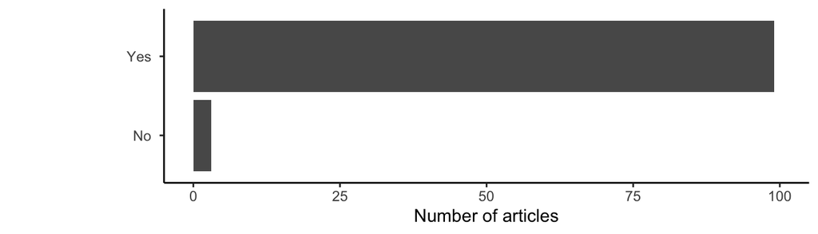

```r
# table(dat$One_categorical_var, useNA = 'always')
dat %>%
    group_by(One_categorical_var) %>%
    count() %>%
    ggplot(aes(x = One_categorical_var, y = n)) + geom_bar(stat = "identity", position = position_dodge(0.9)) +
    coord_flip() + theme_classic() + theme(axis.text.y = element_text(margin = margin(0,
    5, 0, 60))) + xlab("") + ylab("Number of articles") + ylim(0, 100)
```

### 2. How many papers have at least one test for heteroskedasticity (heteroscedasticity)?

**Answer 2.**  
Only 5 papers (4.9%, out of 102 surveyed papers) explicitly tested for heteroskedasticity in their data. [[i.e. tested for homogeneity of variance or heterogeneous variance between different groups.]

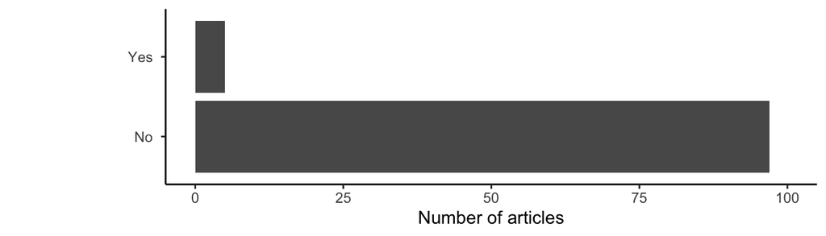

```r
# table(dat$Test_heteroskedasticity, useNA = 'always')
dat %>%
    group_by(Test_heteroskedasticity) %>%
    count() %>%
    ggplot(aes(x = Test_heteroskedasticity, y = n)) + geom_bar(stat = "identity",
    position = position_dodge(0.9)) + coord_flip() + theme_classic() + theme(axis.text.y = element_text(margin = margin(0,
    5, 0, 60))) + xlab("") + ylab("Number of articles") + ylim(0, 100)
```

### 3. How many papers have at least one model in a paper with more than one categorical moderator?

**Answer 3.**  
Almost half of the surveyed papers (41.18%, out of 102 surveyed papers) had more than one categorical variable/moderator included in a statistical model.

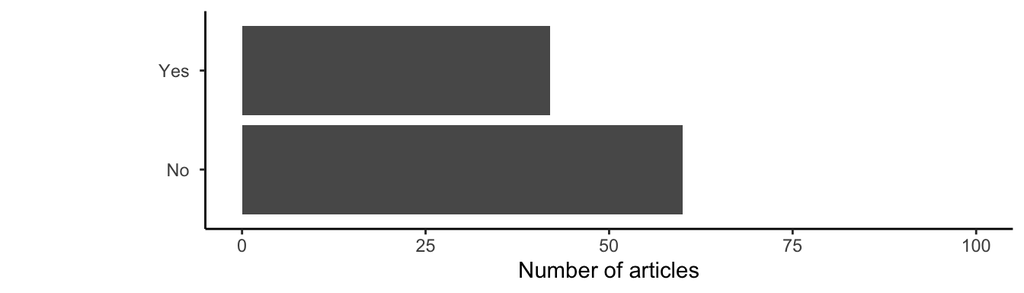

```r
# table(dat$Many_categorical_var, useNA = 'always')
dat %>%
    group_by(Many_categorical_var) %>%
    count() %>%
    ggplot(aes(x = Many_categorical_var, y = n)) + geom_bar(stat = "identity", position = position_dodge(0.9)) +
    coord_flip() + theme_classic() + theme(axis.text.y = element_text(margin = margin(0,
    5, 0, 60))) + xlab("") + ylab("Number of articles") + ylim(0, 100)
```

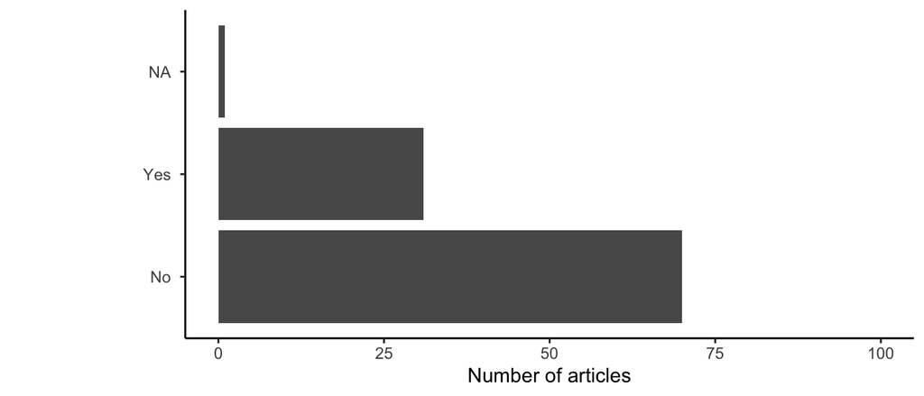

```r
# table(dat$Categorical_cont_var, useNA = 'always')
dat %>%
    group_by(Categorical_cont_var) %>%
    count() %>%
    ggplot(aes(x = Categorical_cont_var, y = n)) + geom_bar(stat = "identity", position = position_dodge(0.9)) +
    coord_flip() + theme_classic() + theme(axis.text.y = element_text(margin = margin(0,
    5, 0, 60))) + xlab("") + ylab("Number of articles") + ylim(0, 100)
```

### 5. How many papers that used a multi-moderator regression have at least one plot (figure) made from a multi-moderator meta-regression?

**Answer 5.**  
Majority of the included papers (72.55%, out of 102 surveyed papers) did not visualise marginalised results of a multi-moderator regression in a plot (figure).

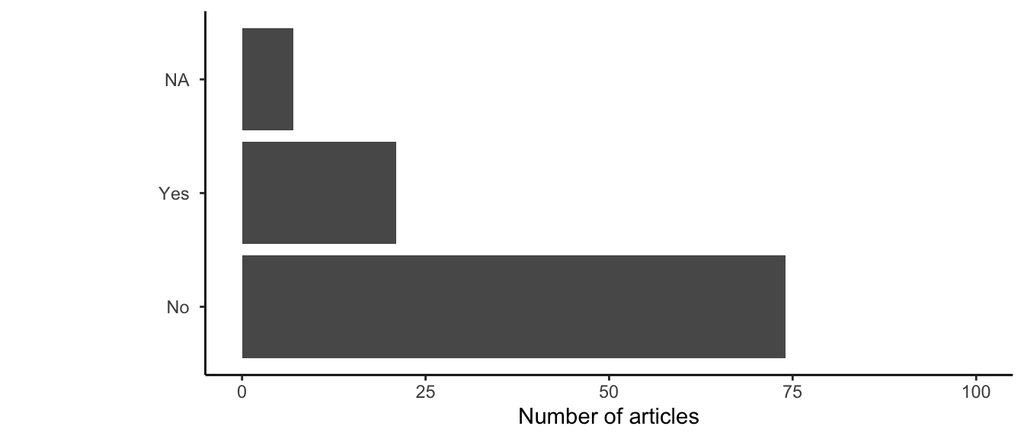

```r
# table(dat$Multimoderator_plot, useNA = 'always')
dat %>%
    group_by(Multimoderator_plot) %>%
    count() %>%
    ggplot(aes(x = Multimoderator_plot, y = n)) + geom_bar(stat = "identity", position = position_dodge(0.9)) +
    coord_flip() + theme_classic() + theme(axis.text.y = element_text(margin = margin(0,
    5, 0, 60))) + xlab("") + ylab("Number of articles") + ylim(0, 100)
```

### 6. How many papers that used a multi-moderator regression also modeled interactions?

**Answer 6.**  
Most (72) papers (70.59%, out of 102 surveyed papers) did not model interactions as part of their statistical models. When interactions were included (one paper could have tested more than one type of interactions), continuous x continuous variable interactions were least frequent (23.33%, out of 30 papers with interactions) . [Note: by interactions we mean statistical interactions between variables in a model, not biological/ecological interactions analysed as effect sizes, e.g. between species.]

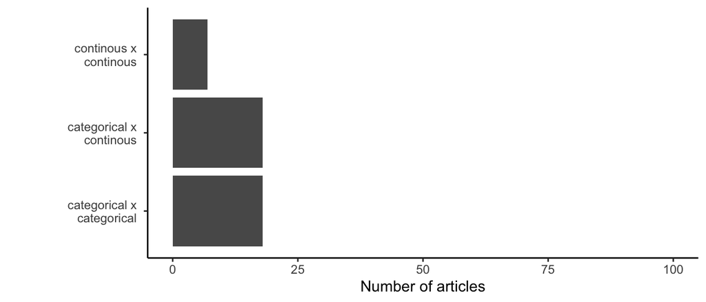

```r
# table(dat$Interactions_mod, useNA = 'always')
dat$Interactions_mod <- str_replace_all(dat$Interactions_mod, ", ", "; ")  #fix  separators

dat %>%
    filter(!is.na(Interactions_mod)) %>%
    filter(Interactions_mod != "No") %>%
    pull(Interactions_mod) %>%
    strsplit("; ") %>%
    unlist() -> Interactions_mod_sep

## fix typos and inconsistencies:
Interactions_mod_sep <- gsub("continious x categorical", "categorical x continious",
    Interactions_mod_sep)
Interactions_mod_sep <- gsub("continious x continuous", "continious x continious",
    Interactions_mod_sep)

table(Interactions_mod_sep) %>%
    as.data.frame() %>%
    ggplot(aes(x = Interactions_mod_sep, y = Freq)) + geom_bar(stat = "identity",
    position = position_dodge(0.9)) + coord_flip() + theme_classic() + theme(axis.text.y = element_text(margin = margin(0,
    5, 0, 30))) + scale_x_discrete(labels = c("categorical x\n categorical", "categorical x\n continous",
    "continous x\n continous")) + xlab("") + ylab("Number of articles") + ylim(0,
    100)
```

### 7. How many papers cite an R software package they used for meta-analysis?

**Answer 7.**  
R packages used for meta-analysis were commonly cited (55 papers, 85.94%, out of 64` surveyed papers that used R).

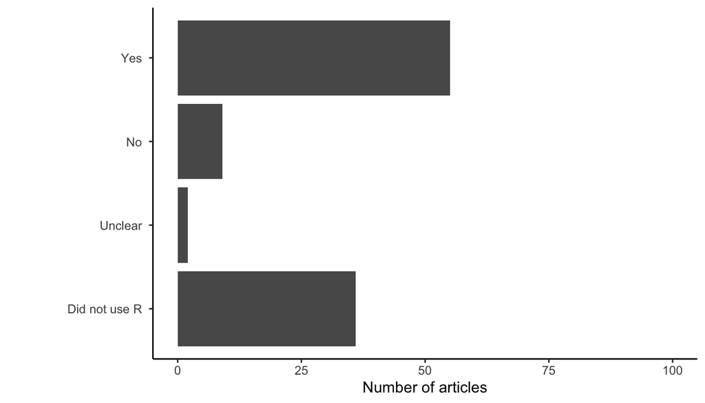

```r
# table(dat$Cited_ma_package, useNA = 'always')

## set the levels in order we want:
dat$Cited_ma_package <- factor(dat$Cited_ma_package, levels = rev(c("Yes", "No",
    "Unclear", "Did not use R")))

dat %>%
    group_by(Cited_ma_package) %>%
    count() %>%
    ggplot(aes(x = Cited_ma_package, y = n)) + geom_bar(stat = "identity", position = position_dodge(0.9)) +
    coord_flip() + theme_classic() + theme(axis.text.y = element_text(margin = margin(0,
    5, 0, 30))) + xlab("") + ylab("Number of articles") + ylim(0, 100)
```

### 8. How many papers cite an R software package they used for graphical presentation of meta-analytic results?

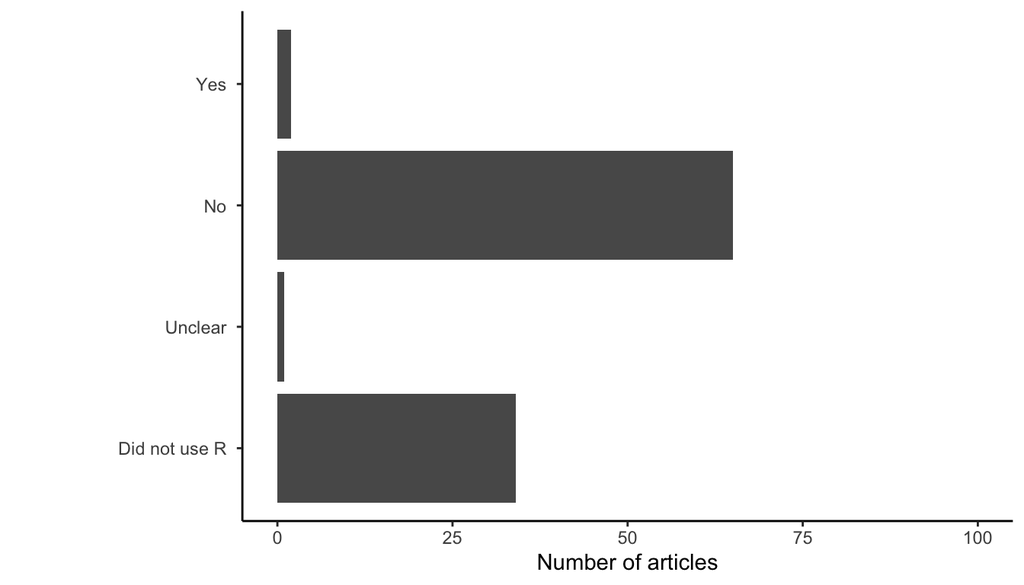

```r
# table(dat$Cited_plot_package, useNA = 'always')

## set the levels in order we want:
dat$Cited_plot_package <- factor(dat$Cited_plot_package, levels = rev(c("Yes", "No",
    "Unclear", "Did not use R")))

dat %>%
    group_by(Cited_plot_package) %>%
    count() %>%
    ggplot(aes(x = Cited_plot_package, y = n)) + geom_bar(stat = "identity", position = position_dodge(0.9)) +
    coord_flip() + theme_classic() + theme(axis.text.y = element_text(margin = margin(0,
    5, 0, 40))) + xlab("") + ylab("Number of articles") + ylim(0, 100)
```